# Mushroom Edibiliy

```python
import pandas as pd
import numpy as np
from sklearn.ensemble import AdaBoostClassifier
from sklearn.tree import DecisionTreeClassifier
from sklearn.datasets import load_breast_cancer
from sklearn.model_selection import train_test_split
from sklearn.metrics import accuracy_score
```

Primary Dataset

```python
labels = ("target","cap shape","cap surface","cap color","bruises?","odor","gill attachment","gill spacing","gill size", "gill color", "stalk shape", "stalk root", "stalk surface above ring", "stalk surface below ring",
                 "stalk color above ring", "stalk color below ring", "veil type", "veil color", "ring number", "ring type",
                 "spore print color", "population", "habitat")
primary_dataset = pd.read_csv("Primary Mushroom Data/agaricus-lepiota.data", header = None, names = labels)
primary_dataset.head()
```

|  | target | cap shape | cap surface | cap color | bruises? | odor | gill attachment | gill spacing | gill size | gill color | ... | stalk surface below ring | stalk color above ring | stalk color below ring | veil type | veil color | ring number | ring type | spore print color | population | habitat |
| --- | --- | --- | --- | --- | --- | --- | --- | --- | --- | --- | --- | --- | --- | --- | --- | --- | --- | --- | --- | --- | --- |
| 0 | p | x | s | n | t | p | f | c | n | k | ... | s | w | w | p | w | o | p | k | s | u |
| 1 | e | x | s | y | t | a | f | c | b | k | ... | s | w | w | p | w | o | p | n | n | g |
| 2 | e | b | s | w | t | l | f | c | b | n | ... | s | w | w | p | w | o | p | n | n | m |
| 3 | p | x | y | w | t | p | f | c | n | n | ... | s | w | w | p | w | o | p | k | s | u |
| 4 | e | x | s | g | f | n | f | w | b | k | ... | s | w | w | p | w | o | e | n | a | g |

5 rows × 23 columns

Data Explanations: Primary Dataset

```
Attribute Information: (classes: edible=e, poisonous=p)
 1. cap-shape:                bell=b,conical=c,convex=x,flat=f,
                              knobbed=k,sunken=s
 2. cap-surface:              fibrous=f,grooves=g,scaly=y,smooth=s
 3. cap-color:                brown=n,buff=b,cinnamon=c,gray=g,green=r,
                              pink=p,purple=u,red=e,white=w,yellow=y
 4. bruises?:                 bruises=t,no=f
 5. odor:                     almond=a,anise=l,creosote=c,fishy=y,foul=f,
                              musty=m,none=n,pungent=p,spicy=s
 6. gill-attachment:          attached=a,descending=d,free=f,notched=n
 7. gill-spacing:             close=c,crowded=w,distant=d
 8. gill-size:                broad=b,narrow=n
 9. gill-color:               black=k,brown=n,buff=b,chocolate=h,gray=g,
                              green=r,orange=o,pink=p,purple=u,red=e,
                              white=w,yellow=y
10. stalk-shape:              enlarging=e,tapering=t
11. stalk-root:               bulbous=b,club=c,cup=u,equal=e,
                              rhizomorphs=z,rooted=r,missing=?
12. stalk-surface-above-ring: fibrous=f,scaly=y,silky=k,smooth=s
13. stalk-surface-below-ring: fibrous=f,scaly=y,silky=k,smooth=s
14. stalk-color-above-ring:   brown=n,buff=b,cinnamon=c,gray=g,orange=o,
                              pink=p,red=e,white=w,yellow=y
15. stalk-color-below-ring:   brown=n,buff=b,cinnamon=c,gray=g,orange=o,
                              pink=p,red=e,white=w,yellow=y
16. veil-type:                partial=p,universal=u
17. veil-color:               brown=n,orange=o,white=w,yellow=y
18. ring-number:              none=n,one=o,two=t
19. ring-type:                cobwebby=c,evanescent=e,flaring=f,large=l,
                              none=n,pendant=p,sheathing=s,zone=z
20. spore-print-color:        black=k,brown=n,buff=b,chocolate=h,green=r,
                              orange=o,purple=u,white=w,yellow=y
21. population:               abundant=a,clustered=c,numerous=n,
                              scattered=s,several=v,solitary=y
22. habitat:                  grasses=g,leaves=l,meadows=m,paths=p,
                              urban=u,waste=w,woods=d
```

Secondary Data Set

```python
second_labels =("target", "cap diameter", "cap shape", "cap surface", "cap color", "bruises?", "gill attachment", "gill spacing",
               "gill color","stalk height", "stalk width","stalk root","stalk surface","stalk color","veil type","veil color","has ring",
               "ring type","spore print color","habitat","season")
secondary_dataset = pd.read_csv("Secondary Mushroom Data/secondary_data.csv", header=None, skiprows=1, names = second_labels, sep=";")
secondary_dataset.head()
# change comma to semicolon (delinator)
# Will have to handle NaNs
```

|  | target | cap diameter | cap shape | cap surface | cap color | bruises? | gill attachment | gill spacing | gill color | stalk height | ... | stalk root | stalk surface | stalk color | veil type | veil color | has ring | ring type | spore print color | habitat | season |
| --- | --- | --- | --- | --- | --- | --- | --- | --- | --- | --- | --- | --- | --- | --- | --- | --- | --- | --- | --- | --- | --- |
| 0 | p | 15.26 | x | g | o | f | e | NaN | w | 16.95 | ... | s | y | w | u | w | t | g | NaN | d | w |
| 1 | p | 16.60 | x | g | o | f | e | NaN | w | 17.99 | ... | s | y | w | u | w | t | g | NaN | d | u |
| 2 | p | 14.07 | x | g | o | f | e | NaN | w | 17.80 | ... | s | y | w | u | w | t | g | NaN | d | w |
| 3 | p | 14.17 | f | h | e | f | e | NaN | w | 15.77 | ... | s | y | w | u | w | t | p | NaN | d | w |
| 4 | p | 14.64 | x | h | o | f | e | NaN | w | 16.53 | ... | s | y | w | u | w | t | p | NaN | d | w |

5 rows × 21 columns

Data Explainations: Secondary Dataset

1. cap-diameter (m): float number in cm
2. cap-shape (n): bell=b, conical=c, convex=x, flat=f, sunken=s, spherical=p, others=o
3. cap-surface (n): fibrous=i, grooves=g, scaly=y, smooth=s, shiny=h, leathery=l, silky=k, sticky=t, wrinkled=w, fleshy=e
4. cap-color (n): brown=n, buff=b, gray=g, green=r, pink=p, purple=u, red=e, white=w, yellow=y, blue=l, orange=o, black=k
5. does-bruise-bleed (n): bruises-or-bleeding=t,no=f
6. gill-attachment (n): adnate=a, adnexed=x, decurrent=d, free=e, sinuate=s, pores=p, none=f, unknown=?
7. gill-spacing (n): close=c, distant=d, none=f
8. gill-color (n): see cap-color + none=f
9. stem-height (m): float number in cm
10. stem-width (m): float number in mm
11. stem-root (n): bulbous=b, swollen=s, club=c, cup=u, equal=e, rhizomorphs=z, rooted=r
12. stem-surface (n): see cap-surface + none=f
13. stem-color (n): see cap-color + none=f
14. veil-type (n): partial=p, universal=u
15. veil-color (n): see cap-color + none=f
16. has-ring (n): ring=t, none=f
17. ring-type (n): cobwebby=c, evanescent=e, flaring=r, grooved=g, large=l, pendant=p, sheathing=s, zone=z, scaly=y, movable=m, none=f, unknown=?
18. spore-print-color (n): see cap color
19. habitat (n): grasses=g, leaves=l, meadows=m, paths=p, heaths=h, urban=u, waste=w, woods=d
20. season (n): spring=s, summer=u, autumn=a, winter=w

Combine data sets

```python
combined_dataset = pd.concat([primary_dataset, secondary_dataset], axis=0, ignore_index=True)
combined_dataset.head()
```

|  | target | cap shape | cap surface | cap color | bruises? | odor | gill attachment | gill spacing | gill size | gill color | ... | spore print color | population | habitat | cap diameter | stalk height | stalk width | stalk surface | stalk color | has ring | season |
| --- | --- | --- | --- | --- | --- | --- | --- | --- | --- | --- | --- | --- | --- | --- | --- | --- | --- | --- | --- | --- | --- |
| 0 | p | x | s | n | t | p | f | c | n | k | ... | k | s | u | NaN | NaN | NaN | NaN | NaN | NaN | NaN |
| 1 | e | x | s | y | t | a | f | c | b | k | ... | n | n | g | NaN | NaN | NaN | NaN | NaN | NaN | NaN |
| 2 | e | b | s | w | t | l | f | c | b | n | ... | n | n | m | NaN | NaN | NaN | NaN | NaN | NaN | NaN |
| 3 | p | x | y | w | t | p | f | c | n | n | ... | k | s | u | NaN | NaN | NaN | NaN | NaN | NaN | NaN |
| 4 | e | x | s | g | f | n | f | w | b | k | ... | n | a | g | NaN | NaN | NaN | NaN | NaN | NaN | NaN |

5 rows × 30 columns

The Data Explainations are above. Stalk color and stalk surface from the secondary dataset may be the same as stalk color above ground and stalk surface above ground, but as I am unsure I do not put them together.

AdaBoost

```python
# Not in use groupings for X
# This is for ease of switching between groups based on feature importance

# Primary Dataset All DT
# X = dataset.drop(["target"], axis=1)

# Primary Dataset Selected DT
# X = dataset[["cap shape","odor","gill size","stalk surface above ring","spore print color","population","habitat"]]

# Primary Dataset ALL RF
# X = dataset.drop(["target"], axis=1)

# Primary Dataset Selected RF
# X = dataset[["cap color", "odor", "stalk color above ring", "veil color", "ring number", "spore print color"]]

# Primary Dataset All SVC
# X = dataset.drop(["target"], axis=1)

# Primary Dataset Selected SVC
# X = dataset[["odor","spore print color","stalk surface below ring","stalk color above ring","habitat","cap color"]]

# Secondary Dataset All DT
# X = dataset.drop(["target","cap diameter","stalk height","stalk width"], axis=1)

# Secondary Dataset Selected DT
# X = dataset[["cap surface","cap color","gill attachment","gill spacing","stalk root","stalk surface","stalk color","ring type"]]
# also remove cap diameter from continous variables

# Secondary Dataset All RF
# X = dataset.drop(["target","cap diameter","stalk height","stalk width"], axis=1)

# Secondary Dataset Selected RF
# X = dataset[["habitat","spore print color"]]
# cap diameter, stalk height, and stalk width are also included in this set, they are just continuous variables

# Secondary Dataset All SVC
# X = dataset.drop(["target","cap diameter","stalk height","stalk width"], axis=1)

# Secondary Dataset Selected SVC
# X = dataset[["spore print color","stalk surface below ring","stalk color above ring","habitat","cap color"]]

# Combined Dataset All DT
# X = dataset.drop(["target","cap diameter","stalk height","stalk width"], axis=1)

# Combined Dataset Selected DT
# X = dataset[["cap surface","cap color","gill attachment","gill spacing","stalk root","stalk surface","stalk color","ring type"]]
# drop cap diameter as well

# Combined Dataset All RF
# X = dataset.drop(["target","cap diameter","stalk height","stalk width"], axis=1)

# Combined Dataset Selected RF

# Combined Dataset All SVC
# Again is this worth running
# X = dataset.drop(["target","cap diameter","stalk height","stalk width"], axis=1)

# Combined Dataset Selected SVC
# X = dataset[["odor","spore print color","stalk surface below ring","stalk color above ring","habitat","cap color"]]
```

```python
from sklearn.preprocessing import LabelEncoder
from sklearn.preprocessing import OneHotEncoder
from sklearn.preprocessing import MinMaxScaler

# choose dataset
dataset = combined_dataset

# label encode y
target_encoder = LabelEncoder()
target_encoded = target_encoder.fit_transform(dataset.target)
# p = 1, e = 0

# one hot encode x
X = dataset.drop(["target","cap diameter","stalk height","stalk width"], axis=1)

feature_encoder = OneHotEncoder(sparse_output=False, feature_name_combiner='concat')
X_encoded = feature_encoder.fit_transform(X)

if dataset is secondary_dataset or dataset is combined_dataset:
    continuous_data = dataset[["cap diameter","stalk height","stalk width"]]

    # handle continuous data (secondary and combined only)
    scaler = MinMaxScaler()
    scaled_data = scaler.fit_transform(continuous_data)
    scaled_data = np.nan_to_num(scaled_data, 0)

    # put scaled data back into main feature array
    X_encoded = np.column_stack((X_encoded, scaled_data))
    print("Continuous variables dealt with")
```

```
Continuous variables dealt with
```

```python
# split the dataset into test and train
X_train, X_test, y_train, y_test = train_test_split(X_encoded, target_encoded, test_size=0.1, random_state=17)
```

```python
from sklearn.svm import SVC
from sklearn.ensemble import RandomForestClassifier

# When unspecified, the estimator is a Decision Tree
SVM = SVC(probability=True,kernel="linear")
RF = RandomForestClassifier()
abc = AdaBoostClassifier(algorithm = 'SAMME')
abc_model = abc.fit(X_train, y_train)
```

```python
predictions = abc_model.predict(X_test)
```

```python
from sklearn.metrics import accuracy_score

# Calculate accuracy
accuracy = accuracy_score(y_test, predictions)
print(f"Accuracy: {accuracy:.2f}")
```

```
Accuracy: 0.73
```

```python
from sklearn.metrics import confusion_matrix

# Compute confusion matrix
cm = confusion_matrix(y_test, predictions)
print("Confusion Matrix:")
print(cm)
```

```
Confusion Matrix:
[[2084 1030]
 [ 838 2968]]
```

```python
from sklearn.metrics import classification_report

# Classification report
report = classification_report(y_test, predictions)
print("Classification Report:")
print(report)
```

```
Classification Report:
              precision    recall  f1-score   support

           0       0.71      0.67      0.69      3114
           1       0.74      0.78      0.76      3806

    accuracy                           0.73      6920
   macro avg       0.73      0.72      0.73      6920
weighted avg       0.73      0.73      0.73      6920
```

```python
from sklearn.model_selection import cross_val_score

# # Perform 5-fold cross-validation
cv_scores = cross_val_score(abc_model, X_encoded, target_encoded, cv=5)
print(f"Cross-validation scores: {cv_scores}")
print(f"Average cross-validation score: {cv_scores.mean():.2f}")
```

```
Cross-validation scores: [0.46383409 0.53739432 0.60416215 0.46422893 0.54465963]
Average cross-validation score: 0.52
```

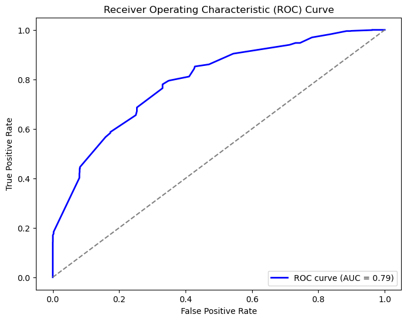

```python
from sklearn.metrics import roc_curve, auc
import matplotlib.pyplot as plt

# Get predicted probabilities (not labels) for the positive class
y_prob = abc_model.predict_proba(X_test)[:, 1]

# Compute ROC curve
fpr, tpr, thresholds = roc_curve(y_test, y_prob)
roc_auc = auc(fpr, tpr)

# Plot ROC curve
plt.figure(figsize=(8, 6))
plt.plot(fpr, tpr, color='blue', lw=2, label=f'ROC curve (AUC = {roc_auc:.2f})')
plt.plot([0, 1], [0, 1], color='gray', linestyle='--')  # Diagonal line (random model)
plt.xlabel('False Positive Rate')
plt.ylabel('True Positive Rate')
plt.title('Receiver Operating Characteristic (ROC) Curve')
plt.legend(loc="lower right")
plt.show()
```

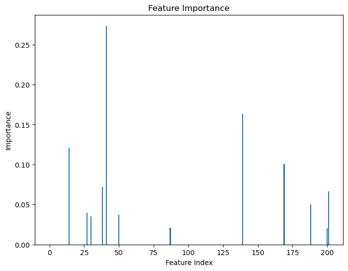

```python
# Get feature importances, this does not work with SVC
importances = abc_model.feature_importances_

# Plot feature importances
plt.figure(figsize=(8, 6))
plt.bar(range(len(importances)), importances)
plt.title('Feature Importance')
plt.xlabel('Feature Index')
plt.ylabel('Importance')
plt.show()
```

```python
# Shows feature importance and names together to make choosing feature groups to try together
if dataset is primary_dataset:
    importance_names = np.column_stack((importances,feature_encoder.get_feature_names_out()))
    print(importance_names)
else:
    feature_names = feature_encoder.get_feature_names_out()
    feature_names = np.append(feature_names,["cap diameter","stalk height","stalk width"])
    importance_names = np.column_stack((importances, feature_names))
    print(importance_names)
```

```
[[0.0 'cap shape_b']
 [0.0 'cap shape_c']
 [0.0 'cap shape_f']
 [0.0 'cap shape_k']
 [0.0 'cap shape_o']
 [0.0 'cap shape_p']
 [0.0 'cap shape_s']
 [0.0 'cap shape_x']
 [0.0 'cap surface_d']
 [0.0 'cap surface_e']
 [0.0 'cap surface_f']
 [0.0 'cap surface_g']
 [0.0 'cap surface_h']
 [0.0 'cap surface_i']
 [0.12110651753403893 'cap surface_k']
 [0.0 'cap surface_l']
 [0.0 'cap surface_s']
 [0.0 'cap surface_t']
 [0.0 'cap surface_w']
 [0.0 'cap surface_y']
 [0.0 'cap surface_nan']
 [0.0 'cap color_b']
 [0.0 'cap color_c']
 [0.0 'cap color_e']
 [0.0 'cap color_g']
 [0.0 'cap color_k']
 [0.0 'cap color_l']
 [0.039839295302391366 'cap color_n']
 [0.0 'cap color_o']
 [0.0 'cap color_p']
 [0.035163873752510025 'cap color_r']
 [0.0 'cap color_u']
 [0.0 'cap color_w']
 [0.0 'cap color_y']
 [0.0 'bruises?_f']
 [0.0 'bruises?_t']
 [0.0 'odor_a']
 [0.0 'odor_c']
 [0.0720299681913489 'odor_f']
 [0.0 'odor_l']
```

[output cut: 147 more lines]

```
 [0.0 'stalk color_u']
 [0.050161117327390814 'stalk color_w']
 [0.0 'stalk color_y']
 [0.0 'stalk color_nan']
 [0.0 'has ring_f']
 [0.0 'has ring_t']
 [0.0 'has ring_nan']
 [0.0 'season_a']
 [0.0 'season_s']
 [0.0 'season_u']
 [0.0 'season_w']
 [0.0 'season_nan']
 [0.0 'cap diameter']
 [0.02027061961028159 'stalk height']
 [0.06623050908159824 'stalk width']]
```